Indicadores migratorios  
Reino Unido

[Observatorio Permanente de la Inmigración (OPI) - S.G de Análisis Migratorio (SGAM)](https://inclusion.seg-social.es/web/opi/estadisticas)

Junio 2023

1. Ciudadanos con documentación de residencia en vigor

2. Ciudadanos con otro tipo de documentación

3. Perfil sociodemográfico y distribución territorial

4. Afiliación en alta laboral y paro registrado

5. Nacionalizados españoles por residencia

6. Evolución de los flujos regulares (visados y documentación de residencia)

7. Población española residente en Reino Unido

# 1. Ciudadanos con documentación de residencia en vigor

**A fecha 31/12/2022 constaban 412.040 ciudadanos de nacionalidad británica con documentación de residencia en vigor en España**:

- 197.428 con documento (TIE) expedido al amparo del Acuerdo de Retirada (iniciado el 6 de julio de 2020) motivado por el Brexit.
- 207.869 con tarjeta de familiar de ciudadano UE/AELC sujetos al régimen de Libre Circulación en virtud de sus vínculos familiares con algún ciudadadano de la UE/AELC; o con certificado de registro de ciudadano UE/AELC, al no haber realizado aún el canje por la TIE del Acuerdo de Retirada, y sujetos al régimen de dicho acuerdo.
- 6.743 con autorización sujetos al régimen de extranjería en alguna de las modalidades previstas en la normativa de extranjería española.

Nacionales de Reino Unido con TIE del Acuerdo de Retirada, con certificado de registro o con tarjeta de familiar de ciudadano UE/AELC, según motivo. 31/12/2022

| Modalidad | Personas | % |
| --- | --- | --- |
| TOTAL | 405.297 | 100 |
| Titular UE-RU. Permanente | 162.108 | 40 |
| Titular UE-RU. Temporal. Motivo de residencia no determinado | 138.754 | 34 |
| Titular UE-RU. Temporal. Residencia no lucrativa | 49.462 | 12 |
| Titular UE-RU. Temporal. Trabajo por cuenta ajena | 25.948 | 6 |
| Titular UE-RU. Temporal. Familiar | 12.451 | 3 |
| Titular UE-RU. Temporal. Estudiante | 7.445 | 2 |
| Titular UE-RU. Temporal. Trabajo por cuenta propia | 6.279 | 2 |
| Familiar de UE-RU. Temporal | 2.804 | 1 |
| Familiar de UE-RU. Permanente | 46 | 0 |

Nota: La información sobre el motivo de expedición del certificado de registro es limitada ya que la obligación de recogerlo no existió hasta 2011. Y para los que disponen de residencia permanente, tampoco se conserva el motivo original por el que se expidió el certificado, antes de que la residencia deviniera permanente (pasados los cinco primeros años). Además, el motivo se refiere solo al motivo en el momento de la primera inscripción, pudiendo haberse modificado en el tiempo sin que se registre con posterioridad.

Fuente: [OPI-SGAM](https://inclusion.seg-social.es/web/opi/estadisticas/catalogo/extranjeros_con_certificado)

Nacionales de Reino Unido con autorización de residencia según motivo de concesión. 31/12/2022

| Motivo | Personas | % |
| --- | --- | --- |
| TOTAL | 6.743 | 100 |
| Residencia temporal no lucrativa | 3.701 | 55 |
| Residencia temporal. Ley 14/2013 y otras | 2.578 | 38 |
| Residencia temporal. Excepción a la autorización de trabajo | 154 | 2 |
| Residencia temporal. Circunstancias excepcionales | 119 | 2 |
| Residencia larga duración nacional | 82 | 1 |
| Residencia temporal. Trabajo por cuenta propia | 40 | 1 |
| Residencia temporal. Trabajo por cuenta ajena | 31 | 0 |
| Residencia temporal. Compatibilidad cuenta ajena y propia | 17 | 0 |
| Residencia temporal. Reagrupación familiar | 9 | 0 |
| Residencia larga duración directiva UE | 6 | 0 |
| Residencia duración determinada. Trabajo por cuenta ajena | 5 | 0 |
| Residencia por protección internacional | 1 | 0 |

Fuente: [OPI-SGAM](https://inclusion.seg-social.es/web/opi/estadisticas/catalogo/extranjeros_con_certificado)

La comunidad de Reino Unido representa un **53% de todos los ciudadanos de Resto de Europa (no UE/AELC) documentados en España.**

Nacionales de Reino Unido con documentación de residencia en España según tipo de documentación en vigor y región. 31/12/2022

| Tipo documentación | Todas las nacionalidades | Nacionales de Resto de Europa (no UE/AELC) | % Resto de Europa (no UE/AELC) respecto Total | NACIONALES DE REINO UNIDO | % Reino Unido respecto Resto de Europa (no UE/AELC) |
| --- | --- | --- | --- | --- | --- |
| TOTAL | 6.493.147 | 780.095 | 12 | 412.040 | 53 |
| Autorización | 2.690.247 | 339.380 | 13 | 6.743 | 2 |
| Certificado de registro y TIE-Acuerdo de retirada (titular) | 3.213.332 | 402.447 | 13 | 402.447 | 100 |
| Tarjeta familiar de UE-RU y TIE-Acuerdo de retirada (familiar) | 589.568 | 38.268 | 6 | 2.850 | 7 |

Fuente: [OPI-SGAM](https://inclusion.seg-social.es/web/opi/estadisticas/catalogo/extranjeros_con_certificado)

**En la UE, España ocupa el puesto 1 en número de extranjeros documentados de Reino Unido**, según datos de Eurostat de finales de 2021.

Nacionales de Reino Unido con permiso de residencia en cada país de la UE/AELC según tiempo de validez del permiso. 31/12/2021

| Orden | País UE/AELC | TOTAL | De 3 a 5 meses | De 6 a 11 meses | 1 año o más |
| --- | --- | --- | --- | --- | --- |
| 1 | España | 408.782 | 75 | 1.079 | 407.628 |
| 2 | Francia | 154.688 | 233 | 2.980 | 151.475 |
| 3 | Países Bajos | 96.308 | 36 | 291 | 95.981 |
| 4 | Suiza | 42.161 | 335 | 386 | 41.440 |
| 5 | Portugal | 41.944 | 0 | 0 | 41.944 |
| 6 | Suecia | 17.480 | 135 | 257 | 17.088 |
| 7 | Noruega | 15.659 | 46 | 236 | 15.377 |
| 8 | Bélgica | 14.813 | 1.157 | 0 | 13.656 |
| 9 | Italia | 12.206 | 2 | 37 | 12.167 |
| 10 | Dinamarca | 12.056 | 0 | 0 | 12.056 |
| 11 | Malta | 9.879 | 10 | 71 | 9.798 |
| 12 | Austria | 8.699 | 0 | 68 | 8.631 |
| 13 | República Checa | 7.760 | 2 | 12 | 7.746 |
| 14 | Bulgaria | 6.838 | 1 | 41 | 6.796 |
| 15 | Polonia | 5.559 | 17 | 132 | 5.410 |
| 16 | Luxemburgo | 3.802 | 1 | 4 | 3.797 |
| 17 | Rumanía | 3.300 | 8 | 16 | 3.276 |
| 18 | Hungría | 2.956 | 15 | 43 | 2.898 |
| 19 | República Eslovaca | 2.793 | 1 | 5 | 2.787 |
| 20 | Chipre | 2.420 | 2 | 60 | 2.358 |
| 21 | Letonia | 1.272 | 0 | 19 | 1.253 |
| 22 | Croacia | 1.212 | 5 | 17 | 1.190 |
| 23 | Eslovenia | 880 | 0 | 2 | 878 |
| 24 | Lituania | 621 | 0 | 4 | 617 |
| 25 | Estonia | 537 | 0 | 3 | 534 |
| 26 | Finlandia * | 513 | : | 5 | 508 |
| 27 | Grecia | 372 | 0 | 0 | 372 |
| 28 | Irlanda | 348 | 1 | 31 | 316 |
| 29 | Alemania | 207 | 0 | 4 | 203 |
| 30 | Liechtenstein | 0 | 0 | 0 | 0 |
| - | Islandia | : | : | : | : |

(*) dato de 2020; (:) dato no disponible

Nota: el número de extranjeros con documentación de residencia publicado por OPI-SGAM y el de extranjeros con permiso de residencia publicado por Eurostat no coinciden por tratarse de diferentes estadísticas e incluir cada una de ellas diferentes tipos de documentación de extranjería.

Fuente: [Eurostat](https://ec.europa.eu/eurostat/databrowser/view/migr_resvalid/default/table?lang=en)

# 2. Ciudadanos con otro tipo de documentación

2.1 Personas con autorización de estancia por estudios

A 31/12/2022 constaban 1.484 nacionales de Reino Unido documentados con una autorización de estancia por estudios, 35% hombres y 65% mujeres.

| Tipo de solicitante | TOTAL | Hombres | Mujeres |
| --- | --- | --- | --- |
| TOTAL | 1.484 | 519 | 965 |
| Estudiante | 1.480 | 515 | 965 |
| Familiar | 4 | 4 | 0 |

Fuente: [OPI-SGAM](https://inclusion.seg-social.es/web/opi/estadisticas/catalogo/extranjeros_estudios)

2.2 Solicitantes de asilo pendientes de resolución

La información publicada en la web pública de Eurostat indica que, a 30/04/2023 (último dato disponible), no había ninguna personas de nacionalidad británica con la solicitud de Protección Internacional pendiente de resolución.

Fuente: [Eurostat](https://ec.europa.eu/eurostat/databrowser/view/migr_asypenctzm/default/table?lang=en)

2.3 Empadronados

A fecha de 01/01/2022, la más reciente con datos publicados para Reino Unido, **constaban empadronados 293.171** nacionales de dicho país. Y a fecha de 31/12/2021 documentados como residentes, estudiantes o solicitantes de asilo pendientes de resolución habría un total de 408.366 personas, 115.195 más que las empadronadas, un 28% más.

| Documentación | Personas |
| --- | --- |
| Empadronados a 01/01/2022 | 293.171 |
| Con documentación de residencia a 31/12/2021 | 407.206 |
| Con autorización de estancia por estudios a 31/12/2021 | 1.160 |
| Solicitantes de asilo pendiente de resolución a 31/12/2021 | 0 |
| Documentados menos empadronados | 115.195 |

Fuente: [Padrón Continuo - INE](https://www.ine.es/dyngs/INEbase/es/operacion.htm?c=Estadistica_C&cid=1254736177012&menu=ultiDatos&idp=1254734710990); [OPI-SGAM](https://inclusion.seg-social.es/web/opi/estadisticas/catalogo); [Eurostat](https://ec.europa.eu/eurostat/databrowser/view/migr_asypenctzm/default/table?lang=en)

# 3. Perfil sociodemográfico y distribución territorial

Nacionales de Reino Unido con documentación de residencia según sexo y grupo de edad. 31/12/2022

| TOTAL | Hombres | % Hombres | Mujeres | % Mujeres |
| --- | --- | --- | --- | --- |
| 412.040 | 210.071 | 51 | 201.969 | 49 |

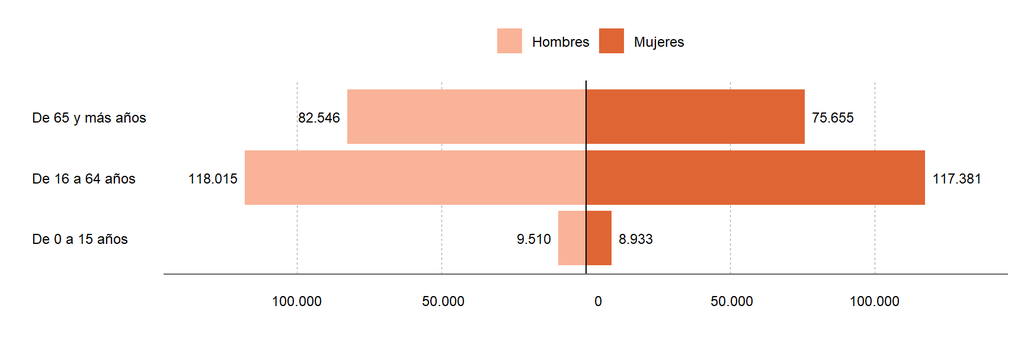

Nacionales de Reino Unido con documentación de residencia según provincia de residencia, 31/12/2022. Cifras absolutas y porcentaje sobre el total de extranjeros residentes de nacionalidad británica

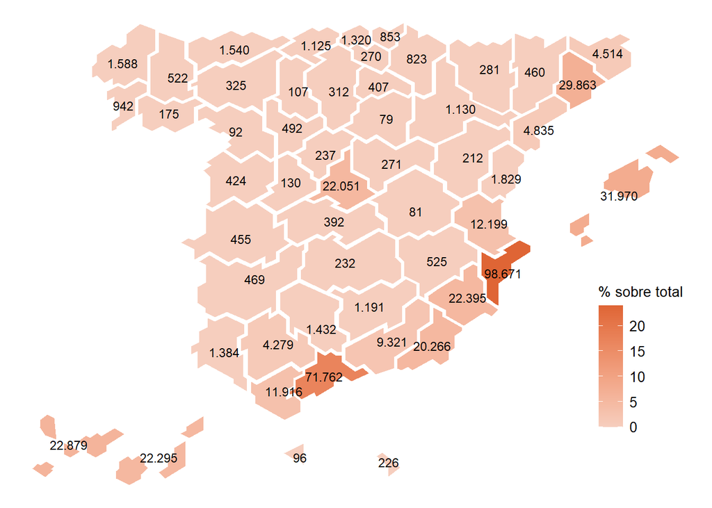

Fuente: [OPI-SGAM](https://inclusion.seg-social.es/web/opi/estadisticas/catalogo/extranjeros_con_certificado)

# 4. Afiliación en alta laboral y paro registrado

4.1 Régimen de afiliación a la Seguridad Social de nacionales de Reino Unido a 28/04/2023

En España hay 67.602 afiliados de Reino Unido, que representan un 4% del total de ciudadanos de países no UE/AELC en alta laboral. 36.378 (54%) son hombres y 31.224 (46%) mujeres.

| Régimen | Afiliados de Reino Unido | Afiliados no UE/AELC | % Reino Unido sobre no UE/AELC |
| --- | --- | --- | --- |
| TOTAL | 67.602 | 1.745.903 | 4 |
| Régimen General | 40.253 | 115.545 | 35 |
| R.E. Autónomos/as | 26.836 | 43.239 | 62 |
| R.G. - S.E. Empleados/as hogar | 244 | 12.706 | 2 |
| R.G. - S.E. Agrario | 161 | 2.710 | 6 |
| R.E. Mar (cuenta ajena) | 91 | 177 | 51 |
| R.E. Mar (cuenta propia) | 17 | 22 | 77 |
| R.E. Minería carbón | 0 | 1 | 0 |

Afiliados nacionales de Reino Unido en alta laboral según régimen y sexo. 28/04/2023

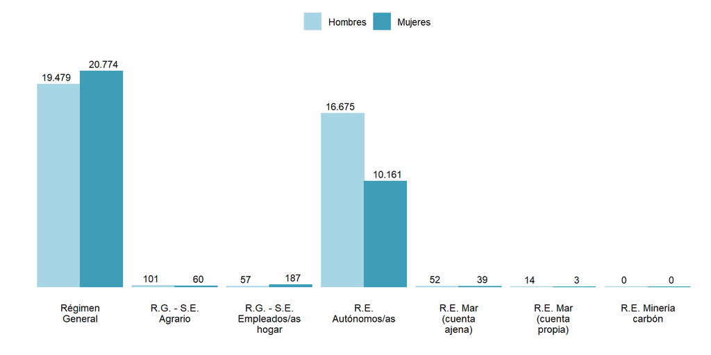

Fuente: [Seguridad Social - MISSM](https://www.seg-social.es/wps/portal/wss/internet/EstadisticasPresupuestosEstudios/Estadisticas/EST8/EST10/EST305/EST307/EST314)

4.2 Parados registrados en el SEPE nacionales de Reino Unido (abril 2023)

Hay en España 3.402 parados registrados nacionales de Reino Unido, 1.492 (44%) hombres y 1.910 (56%) mujeres.

| TOTAL | Sexo Hombres | Sexo Mujeres | Grupo de edad 16-24 años | Grupo de edad 25-34 años | Grupo de edad 35-44 años | Grupo de edad 45-54 años | Grupo de edad 55 y más años |
| --- | --- | --- | --- | --- | --- | --- | --- |
| 3.402 | 1.492 | 1.910 | 131 | 457 | 560 | 806 | 1.448 |
| % | 44 | 56 | 4 | 13 | 16 | 24 | 43 |

Parados registrados en el SEPE nacionales de Reino Unido según comunidad autónoma, abril 2023. Cifras absolutas y porcentaje sobre el total de parados extranjeros registrados de nacionalidad británica

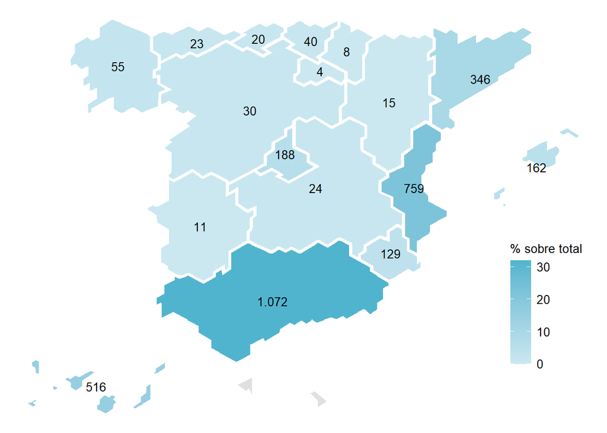

Fuente: [Servicio Público de Empleo Estatal (SEPE)](https://www.sepe.es/HomeSepe/que-es-el-sepe/estadisticas.html)

# 5. Nacionalizados españoles por residencia

Además de la adquisición originaria, el Código Civil considera diferentes modos de **adquisición de la nacionalidad española**:

- **Por adopción**: los extranjeros menores de 18 años adoptados por un español.
- **Por opción**:  
  - Las personas que estén o hayan estado sujetas a la patria potestad de un español.  
  - Las personas cuyo padre o madre hubiera sido originariamente español y nacido en España.  
  - Las personas cuya filiación (identificación de quiénes son sus progenitores) o nacimiento en España se determine después de haber cumplido los 18 años.  
  - Los extranjeros mayores de 18 años adoptados por un español.
- **Por carta de naturaleza**: otorgada discrecionalmente mediante Real Decreto cuando en el interesado concurran circunstancias especiales.
- **Por residencia**, otorgada por el Ministerio de Justicia cuando concurran los siguientes requisitos:  
  1. Haber residido en España un plazo de tiempo que varía según el supuesto.  
  2. La residencia debe ser legal, continuada e inmediatamente anterior a la solicitud.  
  3. El interesado deberá justificar buena conducta cívica y suficiente grado de integración en la sociedad española.
- **Posesión de Estado**: posesión y utilización continuada de la nacionalidad española durante diez años con buena fe y basada en un título inscrito en el Registro Civil.

El 81% del total de adquisiciones de nacionalidad española (no originaria) registradas en el Registro Civil desde 2013 han sido por residencia. En 2022, último periodo publicado por el INE, ese porcentaje fue del 87%.

**Desde 2009 se han nacionalizado españoles por residencia un total de 2.416 personas con nacionalidad previa británica.**

En 2022 obtuvieron la nacionalidad por residencia 415 personas.

Evolución de las concesiones de nacionalidad española por residencia a ciudadanos de Reino Unido. 2009─2022

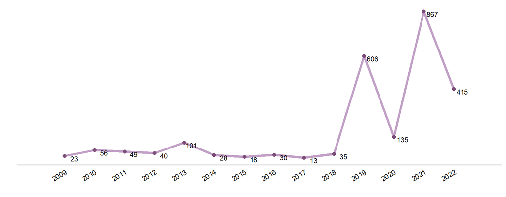

Nota: En 2017 hubo una reducción generalizada de las concesiones de nacionalidad por causas administrativas.

Concesiones de nacionalidad española por residencia a ciudadanos de Reino Unido según plazo exigido / motivo. 2022

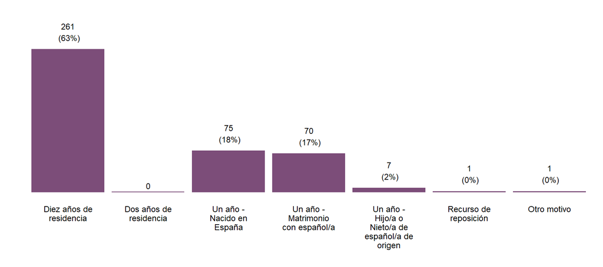

Nota: Existen casos en los que la nacionalidad de origen grabada no coincide con la vía de acceso a la nacionalidad española que debería corresponder según la legislación. Sin embargo, en este momento no se dispone de suficiente información para su correcta depuración.

Concesiones de nacionalidad española por residencia a ciudadanos de Reino Unido según sexo y edad. 2022

| TOTAL | Hombres | % Hombres | Mujeres | % Mujeres |
| --- | --- | --- | --- | --- |
| 415 | 228 | 55 | 187 | 45 |

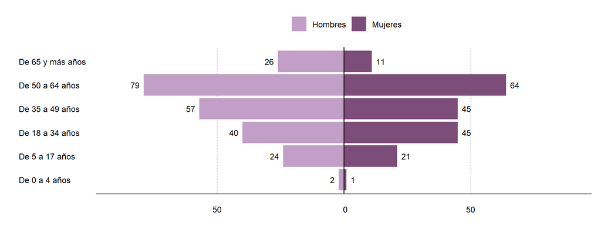

Fuente: [INE](https://www.ine.es/dyngs/INEbase/es/operacion.htm?c=Estadistica_C&cid=1254736177001&menu=resultados&idp=1254735573002), [OPI-SGAM](https://inclusion.seg-social.es/web/opi/estadisticas/catalogo/concesiones_nacionalidad)

# 6. Evolución de los flujos regulares (visados y documentación de residencia)

6.1 Flujo de visados

**A partir del 1 de enero de 2021**, fecha en la que concluyó el periodo transitorio establecido en el Acuerdo de Retirada entre España y Reino Unido motivado por el Brexit, **los británicos necesitan visado** para viajar a países miembros de la Unión Europea, aunque están exentos para estancias de corta duración (hasta 90 días en cualquier período de 180 días) pudiendo acceder a España para periodos no superiores presentando únicamente el pasaporte en vigor.

Evolución de visados concedidos a ciudadanos de Reino Unido según clase de visado. 2013─2022

| Clase | 2013 | 2014 | 2015 | 2016 | 2017 | 2018 | 2019 | 2020 | 2021 | 2022 | % 2022 |
| --- | --- | --- | --- | --- | --- | --- | --- | --- | --- | --- | --- |
| TOTAL | 0 | 0 | 0 | 0 | 0 | 0 | 0 | 0 | 5.290 | 6.995 | 100 |
| Corta duración | 0 | 0 | 0 | 0 | 0 | 0 | 0 | 0 | 1.053 | 147 | 2 |
| Larga duración | 0 | 0 | 0 | 0 | 0 | 0 | 0 | 0 | 4.237 | 6.848 | 98 |
| Tránsito aeroportuario | 0 | 0 | 0 | 0 | 0 | 0 | 0 | 0 | 0 | 0 | 0 |

Evolución de visados concedidos a ciudadanos de Reino Unido según clase de visado de corta o larga duración. 2010─2022

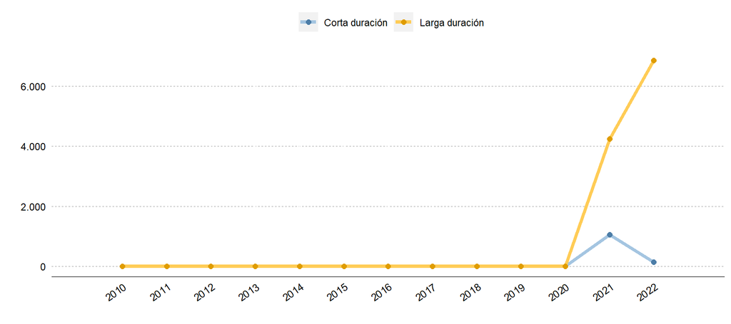

Visados expedidos a nacionales de Reino Unido según clase (corta o larga duración) y tipo/finalidad de visado. 2022

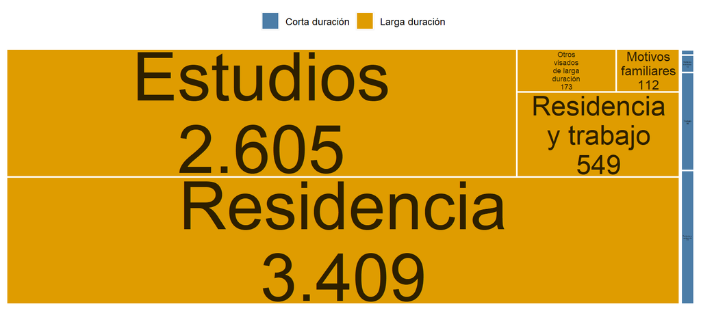

Fuente: [OPI-SGAM](https://inclusion.seg-social.es/web/opi/estadisticas/catalogo/visados)

6.2 Flujo de documentación de residencia

Antes del Brexit, a los británicos residentes en España se les aplicaba el régimen de Libre Circulación UE/AELC y la documentación de residencia que se les expedía era el certificado de registro. **A partir del 6 de julio de 2020, fecha en la que entra en vigor el Acuerdo de Retirada entre España y Reino Unido, surge un nuevo proceso de documentación de residencia** y se empieza a expedir la TIE a los beneficiarios del Acuerdo de Retirada que lo soliciten y, a los que inician su residencia, se les empieza a conceder autorizaciones de residencia del régimen de extranjería o tarjetas de familiar de UE/AELC si tienen vínculos familiares con ciudadanos de la UE/AELC.

En los últimos años se ha concedido o expedido documentación de residencia a nacionales de Reino Unido por los siguientes motivos:

TIE del Acuerdo de Retirada, certificados de registro o tarjetas de familiar de ciudadano UE/AELC expedidas a nacionales de Reino Unido, según motivo. 2017─2021

| Motivo | 2017 | 2018 | 2019 | 2020 | 2021 |
| --- | --- | --- | --- | --- | --- |
| TOTAL | 20.588 | 27.898 | 43.860 | 80.380 | 102.689 |
| Titular UE-RU. Permanente | 4.799 | 6.757 | 10.900 | 31.838 | 62.136 |
| Titular UE-RU. Temporal | 15.782 | 21.139 | 32.955 | 41.376 | 39.409 |
| Familiar de UE-RU. Temporal | 4 | 2 | 5 | 7.158 | 1.123 |
| Familiar de UE-RU. Permanente | 3 | 0 | 0 | 8 | 21 |

Nota: existen casos en los que la nacionalidad grabada es incompatible con el motivo de expedición del certificado de registro, pero en estos momentos no se dispone de suficiente información para su correcta depuración.

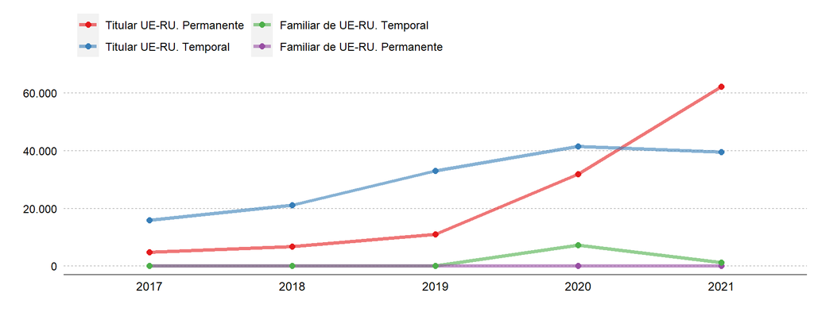

Nota: La estadística de [Nacionales del Reino Unido y sus familias que han solicitado documento de Acuerdo de Retirada](https://www.inclusion.gob.es/web/opi/estadisticas/catalogo/britanicos) (OPI-SGAM) muestra información detallada sobre el flujo mensual de la TIE del Acuerdo de Retirada.

Autorizaciones de residencia de Régimen General concedidas a ciudadanos de Reino Unido según motivo. 2020─2021

| Motivo | 2020 | 2021 |
| --- | --- | --- |
| TOTAL | 2 | 3.316 |
| Residencia temporal no lucrativa | 0 | 1.672 |
| Residencia temporal. Ley 14/2013 y otras | 2 | 1.478 |
| Residencia temporal. Excepción a la autorización de trabajo | 0 | 91 |
| Residencia temporal. Trabajo por cuenta ajena | 0 | 26 |
| Residencia temporal. Circunstancias excepcionales | 0 | 21 |
| Residencia larga duración nacional | 0 | 18 |
| Residencia temporal. Trabajo por cuenta propia | 0 | 9 |
| Residencia duración determinada. Trabajo por cuenta ajena | 0 | 1 |

El siguiente gráfico muestra la **distribución de la documentación de residencia (TIE-Acuerdo Retirada, certificados de registro, tarjetas de familiar de UE/AELC o autorizaciones de residencia) concedida o expedida a nacionales de Reino Unido durante 2021, según tipo de trámite**:

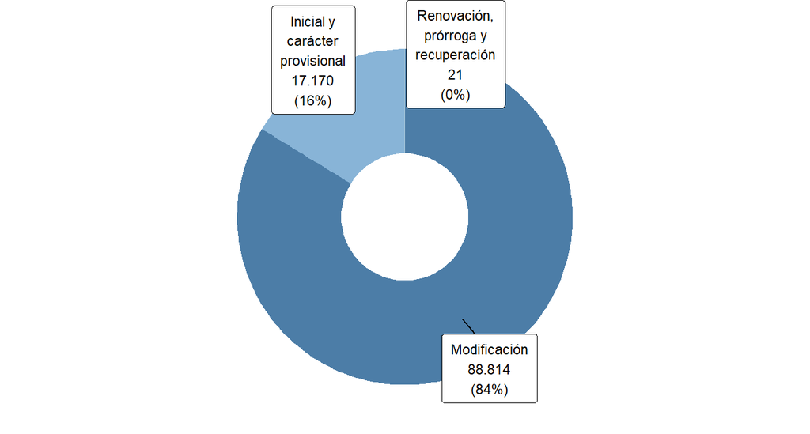

Fuente: [OPI-SGAM](https://www.inclusion.gob.es/web/opi/estadisticas/catalogo/flujo_autorizaciones)

**Comparando con el resto de países de la UE/AELC, el siguiente mapa muestra el número de *primeras* autorizaciones de residencia o de estancia por estudios expedidas a personas de nacionalidad británica durante 2021**, entendiendo como *primera* aquella autorización concedida a una persona si no le fue concedida ninguna otra en los 6 meses anteriores.

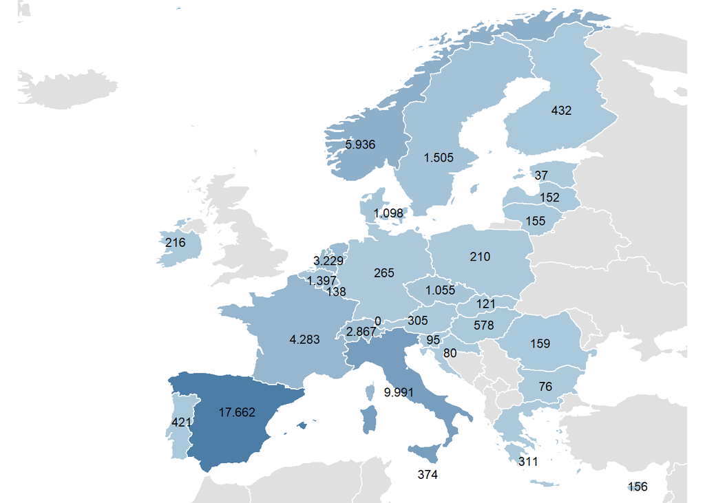

Sin dato disponible: Islandia

Fuente: [Eurostat](https://ec.europa.eu/eurostat/databrowser/view/migr_resfirst/default/table?lang=en)

# 7. Población española residente en Reino Unido

**A 01/01/2023, último dato publicado por el INE, había 181.181 españoles residentes en Reino Unido** inscritos en el fichero central del Padrón de españoles residentes en el extranjero (PERE); suponen el 17% de todos los españoles residentes en países de Europa.

| TOTAL | Hombres | % Hombres | Mujeres | % Mujeres |
| --- | --- | --- | --- | --- |
| 181.181 | 88.102 | 49 | 93.079 | 51 |

Evolución de los españoles residentes en Reino Unido. 2009─2023

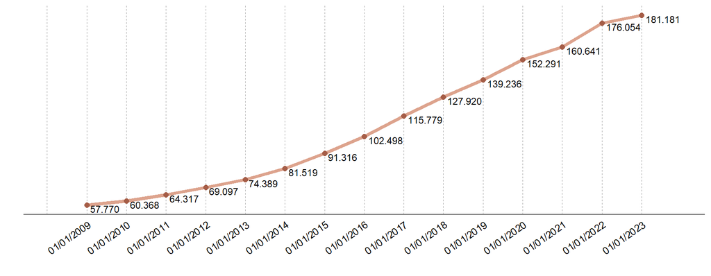

Fuente: [PERE - INE](https://www.ine.es/dyngs/INEbase/operacion.htm?c=Estadistica_C&cid=1254736177014&menu=resultados&secc=1254736195474&idp=1254734710990)